# Data Quality Report e Detecção de Fraudes em Transações Imobiliárias

</br>

## Etapa 1 - Data Quality Report (DQR)

</br>

O DQR é um relatório analítico com o objetivo de compreender a organização dos dados, se estão coerentes, se há alguma anomalia amplamente visível e resumir os dados (ou pelo menos as variáveis mais importantes) com base na compreensão do problema de negócio.

</br>

Para o projeto, foi utilizado uma base de dados fornecida pelo portal de dados abertos da cidade de Nova Yorque.

Você pode acessar o Dicionário de Dados e fazer download do dataset clicando [aqui](https://data.cityofnewyork.us/Housing-Development/Property-Valuation-and-Assessment-Data/rgy2-tti8).

```python
# Versão da linguagem Python
from platform import python_version
print('Versão da linguagem Python usada neste Jupyter Notebook:', python_version())
```

```
Versão da linguagem Python usada neste Jupyter Notebook: 3.8.3
```

### Instalando e Carregando os Pacotes

```python
# Para atualizar um pacote, execute o comando abaixo no terminal ou no prompt de comando:
# pip install -U nome_pacote

# Para instalar a versão exata de um pacote, execute o comando abaixo no terminal ou no prompt de comando:
# !pip install nome_pacote==versão

# Depois de instalar ou atualizar o pacote, reinicie o Jupyter Notebook.

# Instala o pacote watermark.
# Esse pacote é usado para gravar as versões de outros pacotes usados neste Jupyter Notebook.
!pip install -q -U watermark
```

```python
# Imports
import numpy as np
import pandas as pd
import matplotlib.pyplot as plt
import matplotlib.pyplot as pyplot
import seaborn as sns
import warnings
warnings.filterwarnings('ignore') #ignorando possíveis warnings
pd.set_option('display.float_format', lambda x : '%.2f' % x) #configurando o formato dos números decimais para os gráficos
%matplotlib inline
```

```python
# Versões dos pacotes usados neste Jupyter notebook
%reload_ext watermark
%watermark -a "Philip Martins" --iversion
```

```
Author: Philip Martins

seaborn   : 0.11.1
numpy     : 1.18.5
pandas    : 1.0.5
matplotlib: 3.2.2
```

### Resumo dos Dados

```python
# Carregando os dados

dados = pd.read_csv('/pyprojects/data/dataset.csv', index_col = 0)
```

```python
# Shape
dados.shape
```

```
(1070994, 31)
```

```python
# vendo as primeiras linhas do dataset

dados.head()
```

| RECORD | BBLE | B | BLOCK | LOT | EASEMENT | OWNER | BLDGCL | TAXCLASS | LTFRONT | LTDEPTH | ... | BLDFRONT | BLDDEPTH | AVLAND2 | AVTOT2 | EXLAND2 | EXTOT2 | EXCD2 | PERIOD | YEAR | VALTYPE |
| --- | --- | --- | --- | --- | --- | --- | --- | --- | --- | --- | --- | --- | --- | --- | --- | --- | --- | --- | --- | --- | --- |
| 1 | 1000010101 | 1 | 1 | 101 | NaN | U S GOVT LAND & BLDGS | P7 | 4 | 500 | 1046 | ... | 0 | 0 | 3775500.00 | 8613000.00 | 3775500.00 | 8613000.00 | nan | FINAL | 2010/11 | AC-TR |
| 2 | 1000010201 | 1 | 1 | 201 | NaN | U S GOVT LAND & BLDGS | Z9 | 4 | 27 | 0 | ... | 0 | 0 | 11111400.00 | 80690400.00 | 11111400.00 | 80690400.00 | nan | FINAL | 2010/11 | AC-TR |
| 3 | 1000020001 | 1 | 2 | 1 | NaN | DEPT OF GENERAL SERVI | Y7 | 4 | 709 | 564 | ... | 709 | 564 | 32321790.00 | 40179510.00 | 32321790.00 | 40179510.00 | nan | FINAL | 2010/11 | AC-TR |
| 4 | 1000020023 | 1 | 2 | 23 | NaN | DEPARTMENT OF BUSINES | T2 | 4 | 793 | 551 | ... | 85 | 551 | 13644000.00 | 15750000.00 | 13644000.00 | 15750000.00 | nan | FINAL | 2010/11 | AC-TR |
| 5 | 1000030001 | 1 | 3 | 1 | NaN | PARKS AND RECREATION | Q1 | 4 | 323 | 1260 | ... | 89 | 57 | 106348680.00 | 107758350.00 | 106348680.00 | 107758350.00 | nan | FINAL | 2010/11 | AC-TR |

5 rows × 31 columns

```python
# Resumo
print("Linhas: ",dados.shape[0])
print("Colunas: ",dados.shape[1])
print("\nVariáveis: \n", dados.columns.tolist())
print("\nValores Ausentes: \n", dados.isnull().sum())
print("\nValores Únicos: \n", dados.nunique())
```

```
Linhas:  1070994
Colunas:  31

Variáveis:
 ['BBLE', 'B', 'BLOCK', 'LOT', 'EASEMENT', 'OWNER', 'BLDGCL', 'TAXCLASS', 'LTFRONT', 'LTDEPTH', 'EXT', 'STORIES', 'FULLVAL', 'AVLAND', 'AVTOT', 'EXLAND', 'EXTOT', 'EXCD1', 'STADDR', 'ZIP', 'EXMPTCL', 'BLDFRONT', 'BLDDEPTH', 'AVLAND2', 'AVTOT2', 'EXLAND2', 'EXTOT2', 'EXCD2', 'PERIOD', 'YEAR', 'VALTYP…

Valores Ausentes:
 BBLE              0
B                 0
BLOCK             0
LOT               0
EASEMENT    1066358
OWNER         31745
BLDGCL            0
TAXCLASS          0
LTFRONT           0
LTDEPTH           0
EXT          716689
STORIES       56264
FULLVAL           0
AVLAND            0
AVTOT             0
EXLAND            0
EXTOT             0
EXCD1        432506
STADDR          676
ZIP           29890
EXMPTCL     1055415
BLDFRONT          0
BLDDEPTH          0
AVLAND2      788268
AVTOT2       788262
EXLAND2      983545
EXTOT2       940166
EXCD2        978046
PERIOD            0
YEAR              0
VALTYPE           0
dtype: int64

```

[output cut: 18 more lines]

```
EXCD1           129
STADDR       839280
ZIP             196
EXMPTCL          14
BLDFRONT        612
BLDDEPTH        621
AVLAND2       58591
AVTOT2       111360
EXLAND2       22195
EXTOT2        48348
EXCD2            60
PERIOD            1
YEAR              1
VALTYPE           1
dtype: int64
```

```python
# info
dados.info()
```

```
<class 'pandas.core.frame.DataFrame'>
Int64Index: 1070994 entries, 1 to 1070994
Data columns (total 31 columns):
 #   Column    Non-Null Count    Dtype
---  ------    --------------    -----
 0   BBLE      1070994 non-null  object
 1   B         1070994 non-null  int64
 2   BLOCK     1070994 non-null  int64
 3   LOT       1070994 non-null  int64
 4   EASEMENT  4636 non-null     object
 5   OWNER     1039249 non-null  object
 6   BLDGCL    1070994 non-null  object
 7   TAXCLASS  1070994 non-null  object
 8   LTFRONT   1070994 non-null  int64
 9   LTDEPTH   1070994 non-null  int64
```

[output cut: 23 more lines]

```python
# Colunas numéricas (quantitativas)
num_cols = ['LTFRONT', 'LTDEPTH', 'STORIES', 'FULLVAL', 'AVLAND', 'AVTOT', 'EXLAND', 'EXTOT', 'BLDFRONT', 'BLDDEPTH',\
           'AVLAND2', 'AVTOT2', 'EXLAND2', 'EXTOT2']
```

```python
# Colunas Categóricas
cat_cols = ['BBLE', 'B', 'BLOCK', 'LOT', 'EASEMENT', 'OWNER', 'BLDGCL', 'TAXCLASS', 'EXT', 'EXCD1', 'STADDR', 'ZIP', \
           'EXMPTCL', 'EXCD2', 'PERIOD', 'YEAR', 'VALTYPE']
```

```python
# Verificando se separamos todas as colunas
len(num_cols) + len(cat_cols) == 31
```

```
True
```

```python
#Separando o dataset entre variáveis numéricas e categóricas
df_num = dados[num_cols]
df_cat = dados[cat_cols]
```

```python
# Sumário estatístico das variáveis numéricas
summ_num = pd.DataFrame(index = df_num.columns)
summ_num['Tipo de Dado'] = df_num.dtypes.values
summ_num['# Registros Não Nulos'] = df_num.count().values
summ_num['# Registros Não Zero'] = df_num.astype(bool).sum(axis = 0)
summ_num['% Populado'] = round(summ_num['# Registros Não Nulos'] / df_num.shape[0]*100,2)
summ_num['# Valores Únicos'] = df_num.nunique().values
summ_num['Mean'] = round(df_num.mean(),2)
summ_num['Std'] = round(df_num.std(),2)
summ_num['Min'] = round(df_num.min(),2)
summ_num['Max'] = round(df_num.max(),2)
summ_num
```

|  | Tipo de Dado | # Registros Não Nulos | # Registros Não Zero | % Populado | # Valores Únicos | Mean | Std | Min | Max |
| --- | --- | --- | --- | --- | --- | --- | --- | --- | --- |
| LTFRONT | int64 | 1070994 | 901886 | 100.00 | 1297 | 36.64 | 74.03 | 0.00 | 9999.00 |
| LTDEPTH | int64 | 1070994 | 900866 | 100.00 | 1370 | 88.86 | 76.40 | 0.00 | 9999.00 |
| STORIES | float64 | 1014730 | 1070994 | 94.75 | 111 | 5.01 | 8.37 | 1.00 | 119.00 |
| FULLVAL | float64 | 1070994 | 1057987 | 100.00 | 109324 | 874264.51 | 11582430.99 | 0.00 | 6150000000.00 |
| AVLAND | float64 | 1070994 | 1057985 | 100.00 | 70921 | 85067.92 | 4057260.06 | 0.00 | 2668500000.00 |
| AVTOT | float64 | 1070994 | 1057987 | 100.00 | 112914 | 227238.17 | 6877529.31 | 0.00 | 4668308947.00 |
| EXLAND | float64 | 1070994 | 579295 | 100.00 | 33419 | 36423.89 | 3981575.79 | 0.00 | 2668500000.00 |
| EXTOT | float64 | 1070994 | 638422 | 100.00 | 64255 | 91186.98 | 6508402.82 | 0.00 | 4668308947.00 |
| BLDFRONT | int64 | 1070994 | 842179 | 100.00 | 612 | 23.04 | 35.58 | 0.00 | 7575.00 |
| BLDDEPTH | int64 | 1070994 | 842141 | 100.00 | 621 | 39.92 | 42.71 | 0.00 | 9393.00 |
| AVLAND2 | float64 | 282726 | 1070994 | 26.40 | 58591 | 246235.72 | 6178962.56 | 3.00 | 2371005000.00 |
| AVTOT2 | float64 | 282732 | 1070994 | 26.40 | 111360 | 713911.44 | 11652528.95 | 3.00 | 4501180002.00 |
| EXLAND2 | float64 | 87449 | 1070994 | 8.17 | 22195 | 351235.68 | 10802212.67 | 1.00 | 2371005000.00 |
| EXTOT2 | float64 | 130828 | 1070994 | 12.22 | 48348 | 656768.28 | 16072510.17 | 7.00 | 4501180002.00 |

```python
# Sumário estatístico das variáveis categóricas
summ_cat = pd.DataFrame(index = df_cat.columns)
summ_cat['Tipo de Dado'] = df_cat.dtypes.values
summ_cat['# Registros Não Nulos'] = df_cat.count().values
summ_cat['% Populado'] = round(summ_cat['# Registros Não Nulos'] / df_cat.shape[0]*100,2)
summ_cat['# Valores Únicos'] = df_cat.nunique().values
summ_cat
```

|  | Tipo de Dado | # Registros Não Nulos | % Populado | # Valores Únicos |
| --- | --- | --- | --- | --- |
| BBLE | object | 1070994 | 100.00 | 1070994 |
| B | int64 | 1070994 | 100.00 | 5 |
| BLOCK | int64 | 1070994 | 100.00 | 13984 |
| LOT | int64 | 1070994 | 100.00 | 6366 |
| EASEMENT | object | 4636 | 0.43 | 12 |
| OWNER | object | 1039249 | 97.04 | 863346 |
| BLDGCL | object | 1070994 | 100.00 | 200 |
| TAXCLASS | object | 1070994 | 100.00 | 11 |
| EXT | object | 354305 | 33.08 | 3 |
| EXCD1 | float64 | 638488 | 59.62 | 129 |
| STADDR | object | 1070318 | 99.94 | 839280 |
| ZIP | float64 | 1041104 | 97.21 | 196 |
| EXMPTCL | object | 15579 | 1.45 | 14 |
| EXCD2 | float64 | 92948 | 8.68 | 60 |
| PERIOD | object | 1070994 | 100.00 | 1 |
| YEAR | object | 1070994 | 100.00 | 1 |
| VALTYPE | object | 1070994 | 100.00 | 1 |

```python
# Adiciona mais uma coluna com valores mais comuns
temp = []
for col in cat_cols:
    temp.append(df_cat[col].value_counts().idxmax())
summ_cat['Valores Mais Comuns'] = temp
```

```python
summ_cat
```

|  | Tipo de Dado | # Registros Não Nulos | % Populado | # Valores Únicos | Valores Mais Comuns |
| --- | --- | --- | --- | --- | --- |
| BBLE | object | 1070994 | 100.00 | 1070994 | 4095110030 |
| B | int64 | 1070994 | 100.00 | 5 | 4 |
| BLOCK | int64 | 1070994 | 100.00 | 13984 | 3944 |
| LOT | int64 | 1070994 | 100.00 | 6366 | 1 |
| EASEMENT | object | 4636 | 0.43 | 12 | E |
| OWNER | object | 1039249 | 97.04 | 863346 | PARKCHESTER PRESERVAT |
| BLDGCL | object | 1070994 | 100.00 | 200 | R4 |
| TAXCLASS | object | 1070994 | 100.00 | 11 | 1 |
| EXT | object | 354305 | 33.08 | 3 | G |
| EXCD1 | float64 | 638488 | 59.62 | 129 | 1017.00 |
| STADDR | object | 1070318 | 99.94 | 839280 | 501 SURF AVENUE |
| ZIP | float64 | 1041104 | 97.21 | 196 | 10314.00 |
| EXMPTCL | object | 15579 | 1.45 | 14 | X1 |
| EXCD2 | float64 | 92948 | 8.68 | 60 | 1017.00 |
| PERIOD | object | 1070994 | 100.00 | 1 | FINAL |
| YEAR | object | 1070994 | 100.00 | 1 | 2010/11 |
| VALTYPE | object | 1070994 | 100.00 | 1 | AC-TR |

### Identificação, Exploração e Visualização das Variáveis

```python
# Variáveis
dados.columns
```

```
Index(['BBLE', 'B', 'BLOCK', 'LOT', 'EASEMENT', 'OWNER', 'BLDGCL', 'TAXCLASS',
       'LTFRONT', 'LTDEPTH', 'EXT', 'STORIES', 'FULLVAL', 'AVLAND', 'AVTOT',
       'EXLAND', 'EXTOT', 'EXCD1', 'STADDR', 'ZIP', 'EXMPTCL', 'BLDFRONT',
       'BLDDEPTH', 'AVLAND2', 'AVTOT2', 'EXLAND2', 'EXTOT2', 'EXCD2', 'PERIOD',
       'YEAR', 'VALTYPE'],
      dtype='object')
```

```python
# Visualiza
dados.head()
```

| RECORD | BBLE | B | BLOCK | LOT | EASEMENT | OWNER | BLDGCL | TAXCLASS | LTFRONT | LTDEPTH | ... | BLDFRONT | BLDDEPTH | AVLAND2 | AVTOT2 | EXLAND2 | EXTOT2 | EXCD2 | PERIOD | YEAR | VALTYPE |
| --- | --- | --- | --- | --- | --- | --- | --- | --- | --- | --- | --- | --- | --- | --- | --- | --- | --- | --- | --- | --- | --- |
| 1 | 1000010101 | 1 | 1 | 101 | NaN | U S GOVT LAND & BLDGS | P7 | 4 | 500 | 1046 | ... | 0 | 0 | 3775500.00 | 8613000.00 | 3775500.00 | 8613000.00 | nan | FINAL | 2010/11 | AC-TR |
| 2 | 1000010201 | 1 | 1 | 201 | NaN | U S GOVT LAND & BLDGS | Z9 | 4 | 27 | 0 | ... | 0 | 0 | 11111400.00 | 80690400.00 | 11111400.00 | 80690400.00 | nan | FINAL | 2010/11 | AC-TR |
| 3 | 1000020001 | 1 | 2 | 1 | NaN | DEPT OF GENERAL SERVI | Y7 | 4 | 709 | 564 | ... | 709 | 564 | 32321790.00 | 40179510.00 | 32321790.00 | 40179510.00 | nan | FINAL | 2010/11 | AC-TR |
| 4 | 1000020023 | 1 | 2 | 23 | NaN | DEPARTMENT OF BUSINES | T2 | 4 | 793 | 551 | ... | 85 | 551 | 13644000.00 | 15750000.00 | 13644000.00 | 15750000.00 | nan | FINAL | 2010/11 | AC-TR |
| 5 | 1000030001 | 1 | 3 | 1 | NaN | PARKS AND RECREATION | Q1 | 4 | 323 | 1260 | ... | 89 | 57 | 106348680.00 | 107758350.00 | 106348680.00 | 107758350.00 | nan | FINAL | 2010/11 | AC-TR |

5 rows × 31 columns

**Variável 1** \ Nome da Variável: BBLE \ Descrição: Concatenação de código Borough, código de bloco, código LOT; um número exclusivo para cada registro.

**Variável 2** \ Nome da Variável: B \ Descrição: Códigos Borough

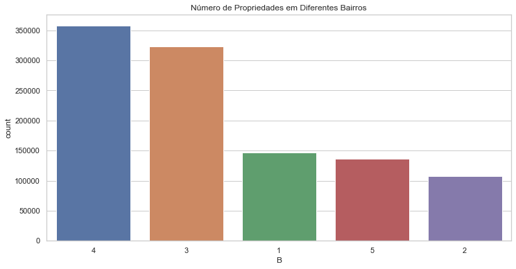

```python
# Visualização da variável 2
sns.set_theme(style = 'whitegrid')
plt.figure(figsize = (12, 6))
fig1 = sns.countplot(x = 'B', data = dados, order = dados['B'].value_counts().index)
plt.title("Número de Propriedades em Diferentes Bairros")
```

```python
# Contagem
BLOCK = df_cat['BLOCK'].value_counts().rename_axis('Unique_values_BLOCK').reset_index(name = 'Counts')
BLOCK[:15]
```

|  | Unique_values_BLOCK | Counts |
| --- | --- | --- |
| 0 | 3944 | 3888 |
| 1 | 16 | 3786 |
| 2 | 3943 | 3424 |
| 3 | 3938 | 2794 |
| 4 | 1171 | 2535 |
| 5 | 3937 | 2275 |
| 6 | 1833 | 1774 |
| 7 | 2450 | 1651 |
| 8 | 1047 | 1480 |
| 9 | 7279 | 1302 |
| 10 | 5893 | 1295 |
| 11 | 8720 | 1281 |
| 12 | 936 | 1151 |
| 13 | 1115 | 1090 |
| 14 | 1320 | 1049 |

**Variável 4** \ Nome da Variável: LOT \ Descrição: Número de até 4 dígitos que representam códigos de lote em diferentes Borough & Block

```python
# Contagem
LOT = df_cat['LOT'].value_counts().rename_axis('Unique_values_LOT').reset_index(name = 'Counts')[:15]
LOT[:15]
```

|  | Unique_values_LOT | Counts |
| --- | --- | --- |
| 0 | 1 | 24367 |
| 1 | 20 | 12294 |
| 2 | 15 | 12171 |
| 3 | 12 | 12143 |
| 4 | 14 | 12074 |
| 5 | 16 | 12042 |
| 6 | 17 | 11982 |
| 7 | 18 | 11979 |
| 8 | 25 | 11949 |
| 9 | 21 | 11840 |
| 10 | 23 | 11705 |
| 11 | 22 | 11665 |
| 12 | 6 | 11646 |
| 13 | 19 | 11640 |
| 14 | 30 | 11596 |

**Variável 5** \ Nome da Variável: EASEMENT \ Descrição: Tipos de easement

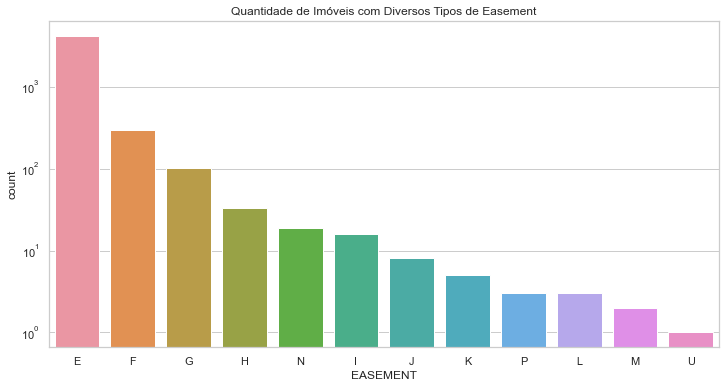

```python
# Visualização da variável 5
sns.set_theme(style = 'whitegrid')
plt.figure(figsize = (12, 6))
fig2 = sns.countplot(x = 'EASEMENT', data = dados, order = dados['EASEMENT'].value_counts().index)
fig2.set_yscale("log")
fig2.set_title('Quantidade de Imóveis com Diversos Tipos de Easement')
```

**Variável 6** \ Nome da Variável: OWNER \ Descrição: Proprietários dos imóveis

```python
# Contagem
OWNER = df_cat['OWNER'].value_counts().rename_axis('Unique_values_OWNER').reset_index(name = 'Counts')
```

```python
OWNER.head()
```

|  | Unique_values_OWNER | Counts |
| --- | --- | --- |
| 0 | PARKCHESTER PRESERVAT | 6020 |
| 1 | PARKS AND RECREATION | 4255 |
| 2 | DCAS | 2169 |
| 3 | HOUSING PRESERVATION | 1904 |
| 4 | CITY OF NEW YORK | 1450 |

```python
OWNER.tail()
```

|  | Unique_values_OWNER | Counts |
| --- | --- | --- |
| 863341 | ANTONIOS BAKIS | 1 |
| 863342 | BEDNARCZYK THOMAS | 1 |
| 863343 | 3125 BAINBRIDGE AVE | 1 |
| 863344 | NITSKANSKY, HELEN E | 1 |
| 863345 | MITRANI, JONATHAN | 1 |

**Variável 7** \ Nome da Variável: BLDGCL \ Descrição: Classe do imóvel

```python
# Contagem
BLDGCL = df_cat['BLDGCL'].value_counts().rename_axis('Unique_values_BLDCGL').reset_index(name = 'Counts')
```

```python
BLDGCL.tail()
```

|  | Unique_values_BLDCGL | Counts |
| --- | --- | --- |
| 195 | I2 | 4 |
| 196 | I3 | 4 |
| 197 | H7 | 3 |
| 198 | Y5 | 1 |
| 199 | E6 | 1 |

```python
BLDGCL.head()
```

|  | Unique_values_BLDCGL | Counts |
| --- | --- | --- |
| 0 | R4 | 139879 |
| 1 | A1 | 123369 |
| 2 | A5 | 96984 |
| 3 | B1 | 84208 |
| 4 | B2 | 77598 |

**Variável 9** \ Nome da Variável: LTFRONT \ Descrição: Frente do lote em pés (feet)

```python
# Divide em percentis
dados['LTFRONT'].describe(percentiles = [0.5,0.75,0.995])
```

```
count   1070994.00
mean         36.64
std          74.03
min           0.00
50%          25.00
75%          40.00
99.5%       375.00
max        9999.00
Name: LTFRONT, dtype: float64
```

```python
# Filtra por valores iguais ou menores que 375
tmp = dados[dados['LTFRONT'] <= 375]
```

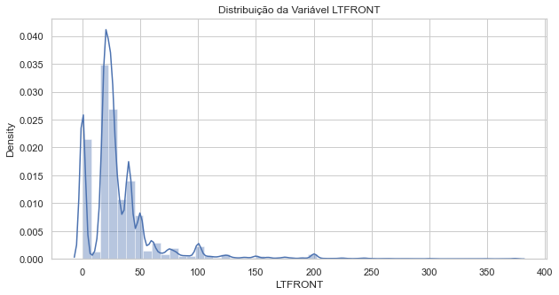

```python
# Visualização da variável 9
sns.set_theme(style = 'whitegrid')
plt.figure(figsize = (10, 5))
fig4 = sns.distplot(tmp.LTFRONT, bins = 50)
fig4.set_title('Distribuição da Variável LTFRONT')
```